# Exercises and Solutions - Analysis of High-Dimensional Data

# 15 Decision trees, Random Forest and AdaBoost

In this exercise we explore decision trees based on the South African heart disease data `sahd.rds`.

The solution to this exercise.

First we read the data and grow the tree.

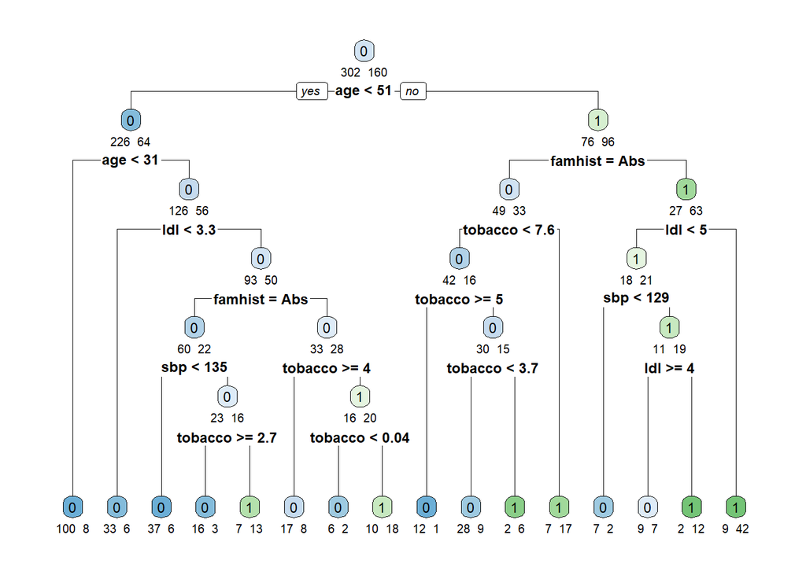

```r
# load packages
library(rpart)
library(rpart.plot)

# read data set
sahd <- readRDS(file="data/sahd.rds")

# grow a classification tree
fit.tree <- rpart(chd~.,data=sahd,method="class")
rpart.plot(fit.tree,extra=1,under=TRUE,tweak = 1.2,faclen=3)
```

We re-grow the tree using different control parameters.

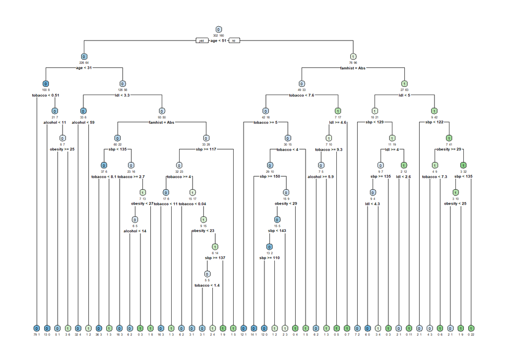

```r
# controlling the growth of the tree with rpart.control
# cp: improvement in each split needs to be > cp
# minsplit: minimal number of samples in a node in order to do a split
fit.tree2 <- rpart(chd~.,data=sahd,method="class",
                   control = rpart.control(cp = 0,minsplit=10)

)
rpart.plot(fit.tree2,extra=1,under=TRUE,tweak = 1.2,faclen=3)
```

We can get the tree size from the cptable (tree size=number of leaves=number splits+1).

```r
fit.tree2$cptable[fit.tree2$cptable[,"CP"]==0,"nsplit"]+1 # number of leaves
```

```
## [1] 43
```

Next, we plot the cross-validation error against the complexity parameter $\alpha$. A tree of size $4$ has smallest cross-validation error.

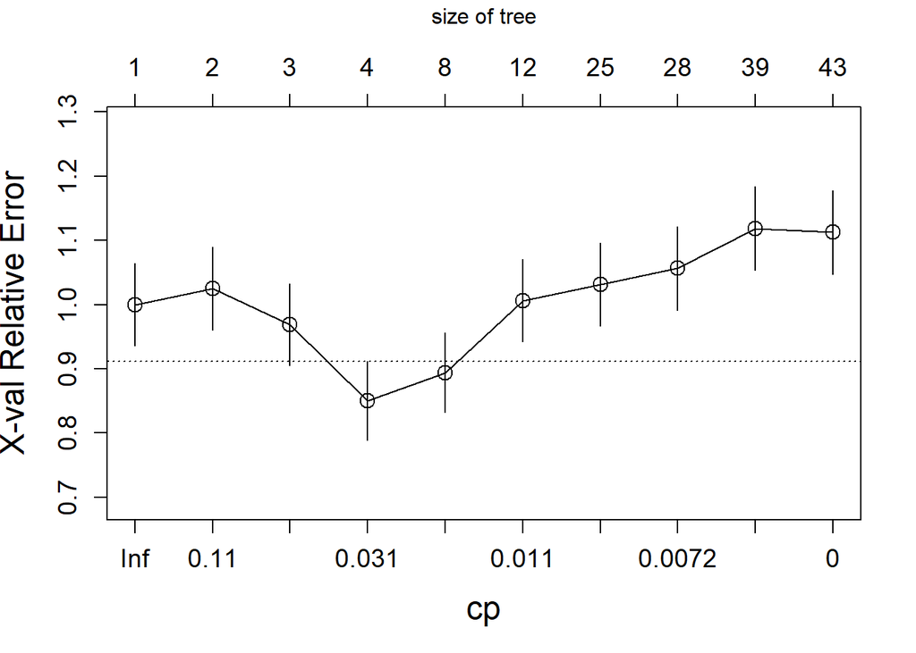

```r
plotcp(fit.tree2,cex.lab=1.5,cex.axis=1.2,cex=1.5)
```

We prune the tree and visualize the result.

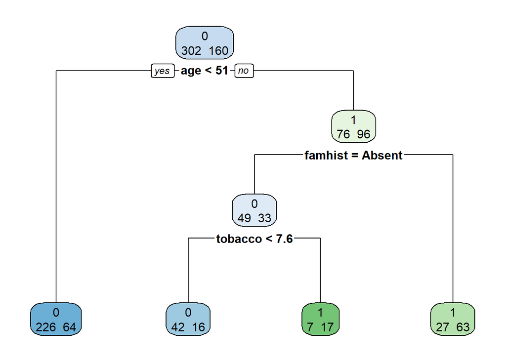

```r
# prune the tree
fit.prune<- prune(fit.tree2,
                  cp=fit.tree2$cptable[which.min(fit.tree2$cptable[,"xerror"]),"CP"])
rpart.plot(fit.prune,extra=1)
```

Finally, we compute the confusion matrix and the misclassification error.

```r
# confusion matrix of actual and fitted class labels
table(Actual=sahd$chd,Fitted=predict(fit.prune,type="class"))
```

```
##       Fitted
## Actual   0   1
##      0 268  34
##      1  80  80
```

```r
# misclassification error
mean(sahd$chd!=predict(fit.prune,type="class"))
```

```
## [1] 0.2467532
```

We sample with replacement (bootstrap sample).

```r
set.seed(1)
inthebag <- sample(1:nrow(sahd),size=nrow(sahd),replace=TRUE)
outofbag <- setdiff(1:nrow(sahd),inthebag)
```

We fit a tree on the in-the-bag samples and calculate the misclassification error on the out-of-bag samples.

```r
fit.in <- rpart(chd~.,data=sahd[inthebag,],method="class")
pred.oob <- predict(fit.in,newdata=sahd[outofbag,],type="class")
mean(sahd$chd[outofbag]!=pred.oob)
```

```
## [1] 0.3559322
```

We fit the random forest, plot the error as a function of the number of trees and plot the variable importance. The out-of-bag error estimate (black line) stabilizes with increasing number of fitted trees.

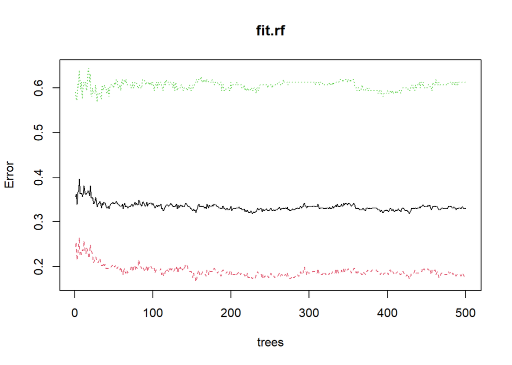

```r
library(randomForest)
sahd$chd <- factor(sahd$chd)
fit.rf <- randomForest(chd~.,data=sahd,importance=TRUE)
plot(fit.rf)
```

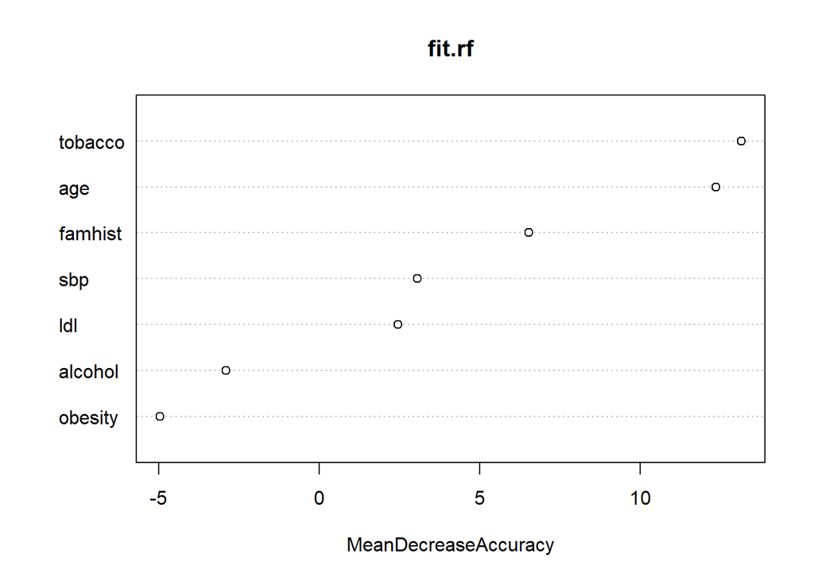

```r
varImpPlot(fit.rf,type=1)
```

# 16 Email spam and data mining

In this exercise we explore a typical data mining task. We use the `spam.rds` data set. The data for this example consists of information from 4601 email messages. The aim is to predict whether the email is spam. For all 4601 email messages, the true outcome (email type) “email” or “spam” is available, along with the relative frequencies of 57 of the most commonly occurring words and punctuation marks in the email message. This is a supervised learning problem, with the outcome the class variable email/spam. It is also called a classification problem.

1. Read the data set and partition it into 2/3 of training and 1/3 of test data.
2. Use `rpart` to fit a decision tree. Examine the cross-validation output, prune the tree and calculate the misclassification error.
3. Use `randomForest`, calculate the misclassification error and plot the variable importance. How do you check whether the number of fitted trees was sufficient?
4. Use `gbm` to perform boosting with `distribution="bernoulli"`. How do you set the tuning parameters, i.e. tree size, shrinkage factor and the number of boosting iterations? Calculate the misclassication error and plot the relative influence of the variables.

The solution to the exercise.

We read the data and divide into 2/3 training and 1/3 test data.

```r
spam <- readRDS(file="data/spam.rds")
set.seed(102)
train <- sort(sample(nrow(spam),3065))
spam.train<- spam[train,]
spam.test<- spam[-train,]
```

We grow a classification tree and examine the 10-fold cross-validation output.

```r
# grow tree
library(rpart)
fit.rpart <- rpart(spam~.,data=spam.train,method='class',cp=1e-5)

# cross-validation output
t.tab <- printcp(fit.rpart)
```

```
##
## Classification tree:
## rpart(formula = spam ~ ., data = spam.train, method = "class",
##     cp = 1e-05)
##
## Variables actually used in tree construction:
##  [1] capavg      caplong     captot      cf.dollar   cf.exclaim  wf.000
##  [7] wf.650      wf.all      wf.business wf.edu      wf.free     wf.george
## [13] wf.hp       wf.hpl      wf.internet wf.money    wf.our      wf.over
## [19] wf.pm       wf.re       wf.remove   wf.you      wf.your
##
## Root node error: 1223/3065 = 0.39902
##
## n= 3065
##
##            CP nsplit rel error  xerror     xstd
## 1  0.48569092      0   1.00000 1.00000 0.022167
## 2  0.06868357      1   0.51431 0.53557 0.018556
## 3  0.06132461      2   0.44563 0.44481 0.017296
## 4  0.02698283      4   0.32298 0.33279 0.015361
## 5  0.02371218      5   0.29599 0.31562 0.015019
## 6  0.01635323      6   0.27228 0.29027 0.014486
## 7  0.01471791      7   0.25593 0.28618 0.014397
## 8  0.00735895      8   0.24121 0.26574 0.013937
## 9  0.00572363      9   0.23385 0.26165 0.013842
## 10 0.00490597     11   0.22240 0.25675 0.013727
## 11 0.00408831     13   0.21259 0.24612 0.013471
## 12 0.00327065     19   0.18806 0.24285 0.013391
## 13 0.00245298     22   0.17825 0.23385 0.013167
## 14 0.00218043     24   0.17334 0.22567 0.012958
## 15 0.00163532     27   0.16680 0.22077 0.012830
## 16 0.00130826     36   0.15127 0.21668 0.012722
## 17 0.00081766     41   0.14473 0.21504 0.012679
## 18 0.00040883     47   0.13982 0.20932 0.012524
## 19 0.00001000     51   0.13818 0.20769 0.012480
```

```r
kable(t.tab,digits = 3,booktabs=TRUE)
```

| CP | nsplit | rel error | xerror | xstd |
| --- | --- | --- | --- | --- |
| 0.486 | 0 | 1.000 | 1.000 | 0.022 |
| 0.069 | 1 | 0.514 | 0.536 | 0.019 |
| 0.061 | 2 | 0.446 | 0.445 | 0.017 |
| 0.027 | 4 | 0.323 | 0.333 | 0.015 |
| 0.024 | 5 | 0.296 | 0.316 | 0.015 |
| 0.016 | 6 | 0.272 | 0.290 | 0.014 |
| 0.015 | 7 | 0.256 | 0.286 | 0.014 |
| 0.007 | 8 | 0.241 | 0.266 | 0.014 |
| 0.006 | 9 | 0.234 | 0.262 | 0.014 |
| 0.005 | 11 | 0.222 | 0.257 | 0.014 |
| 0.004 | 13 | 0.213 | 0.246 | 0.013 |
| 0.003 | 19 | 0.188 | 0.243 | 0.013 |
| 0.002 | 22 | 0.178 | 0.234 | 0.013 |
| 0.002 | 24 | 0.173 | 0.226 | 0.013 |
| 0.002 | 27 | 0.167 | 0.221 | 0.013 |
| 0.001 | 36 | 0.151 | 0.217 | 0.013 |
| 0.001 | 41 | 0.145 | 0.215 | 0.013 |
| 0.000 | 47 | 0.140 | 0.209 | 0.013 |
| 0.000 | 51 | 0.138 | 0.208 | 0.012 |

We prune the tree and visualize the result.

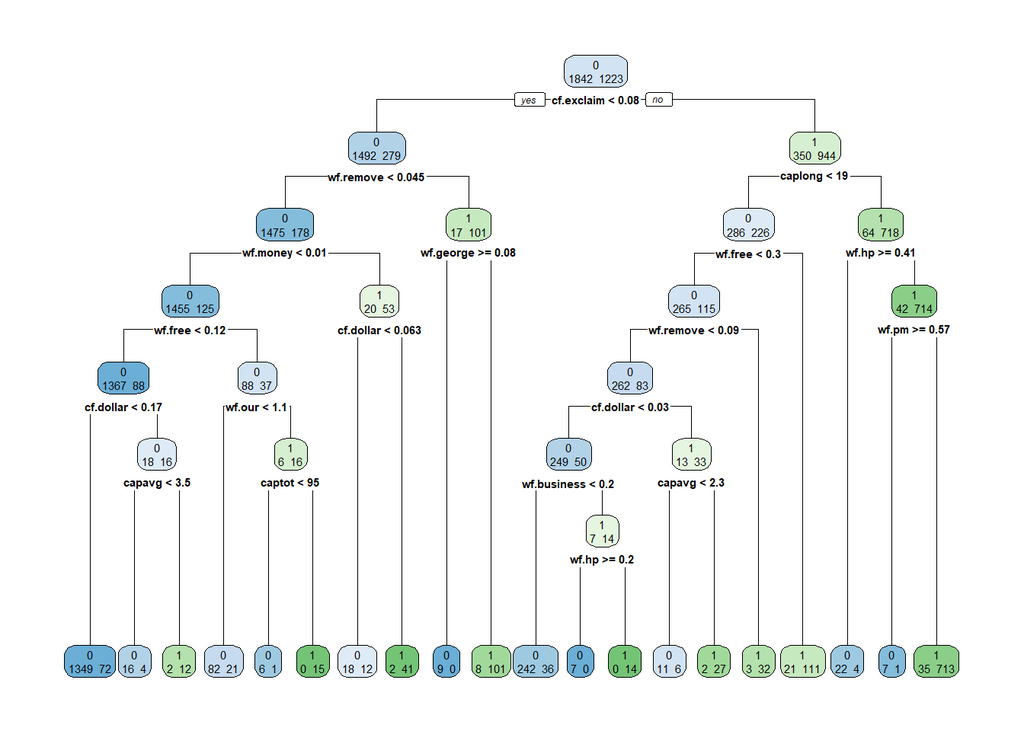

```r
fit.rpart2 <- prune(fit.rpart,cp=.0033)
rpart.plot(fit.rpart2,extra=1)
```

We compute the misclassification error.

```r
(err.rpart2 <- mean(spam.test$spam!=predict(fit.rpart2,newdata=spam.test,type="class")))
```

```
## [1] 0.09570312
```

We fit the random forest, calculate the misclassification error and plot the variable importance.

```r
fit.rf <- randomForest(spam ~ .,
                       data = spam.train%>%
                         dplyr::mutate(spam=factor(spam)),
                       ntree = 200,
                       importance=TRUE)
fit.rf
```

```
##
## Call:
##  randomForest(formula = spam ~ ., data = spam.train %>% dplyr::mutate(spam = factor(spam)),      ntree = 200, importance = TRUE)
##                Type of random forest: classification
##                      Number of trees: 200
## No. of variables tried at each split: 7
##
##         OOB estimate of  error rate: 4.86%
## Confusion matrix:
##      0    1 class.error
## 0 1791   51  0.02768730
## 1   98 1125  0.08013083
```

```r
(err.rf <- mean(spam.test$spam!=predict(fit.rf,newdata=spam.test)))
```

```
## [1] 0.05403646
```

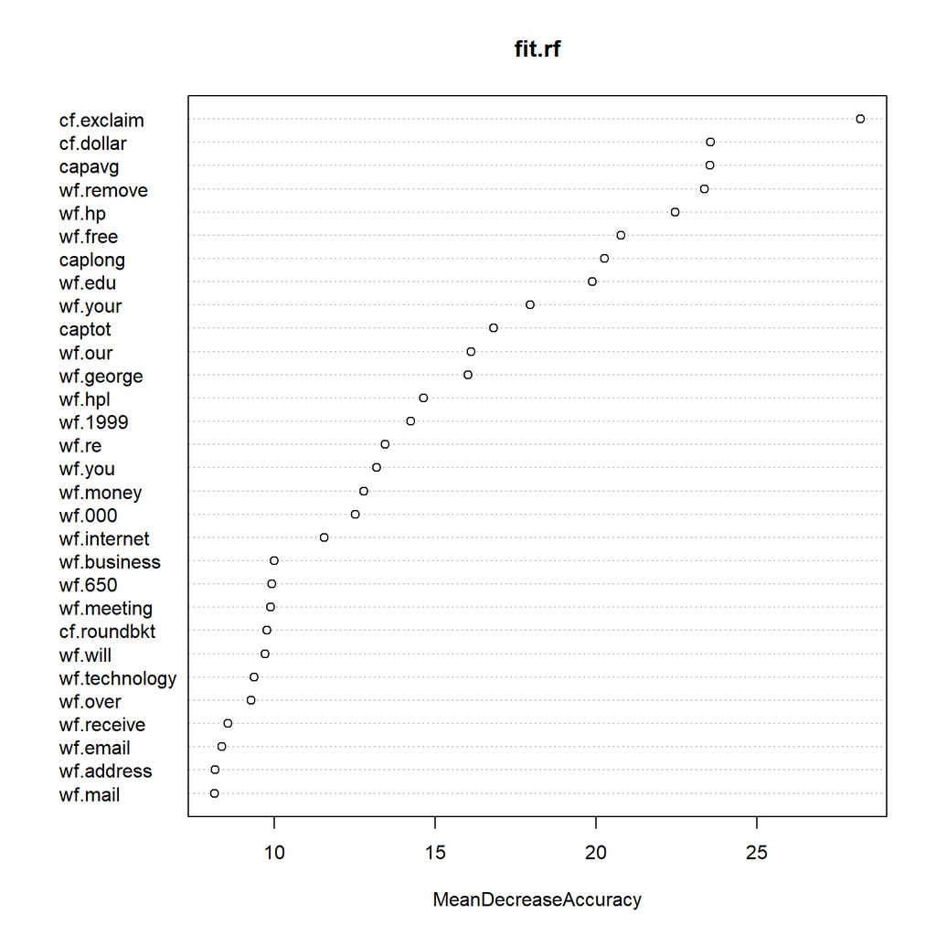

```r
varImpPlot(fit.rf,type=1)
```

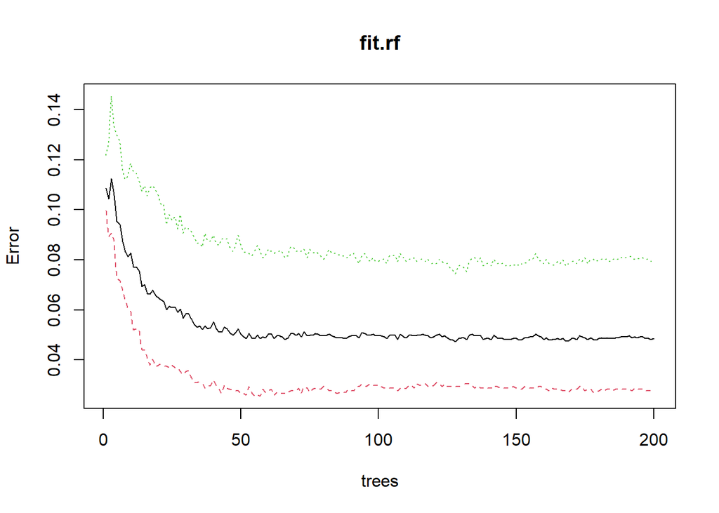

```r
plot(fit.rf)
```

We run gradient boosting `gbm` with `distribution = "bernoulli"` and tuning parameters `shrinkage=0.1`, `interaction.depth=3` and `n.trees=1000`. In addition we perform cross-validation `cv.folds=5` in order to monitor performance as a function of the boosting iterations.

```r
library(gbm)
fit.boost <-gbm(spam~.,
                data=spam.train,
                distribution = "bernoulli",
                shrinkage=0.1,
                n.trees=1000,
                interaction.depth = 3,
                cv.folds=5)
fit.boost
```

```
## gbm(formula = spam ~ ., distribution = "bernoulli", data = spam.train,
##     n.trees = 1000, interaction.depth = 3, shrinkage = 0.1, cv.folds = 5)
## A gradient boosted model with bernoulli loss function.
## 1000 iterations were performed.
## The best cross-validation iteration was 361.
## There were 57 predictors of which 48 had non-zero influence.
```

We explore the performance as a function of the number of boosting iterations.

```r
# find index for n trees with minimum CV error
which.min(fit.boost$cv.error)
```

```
## [1] 361
```

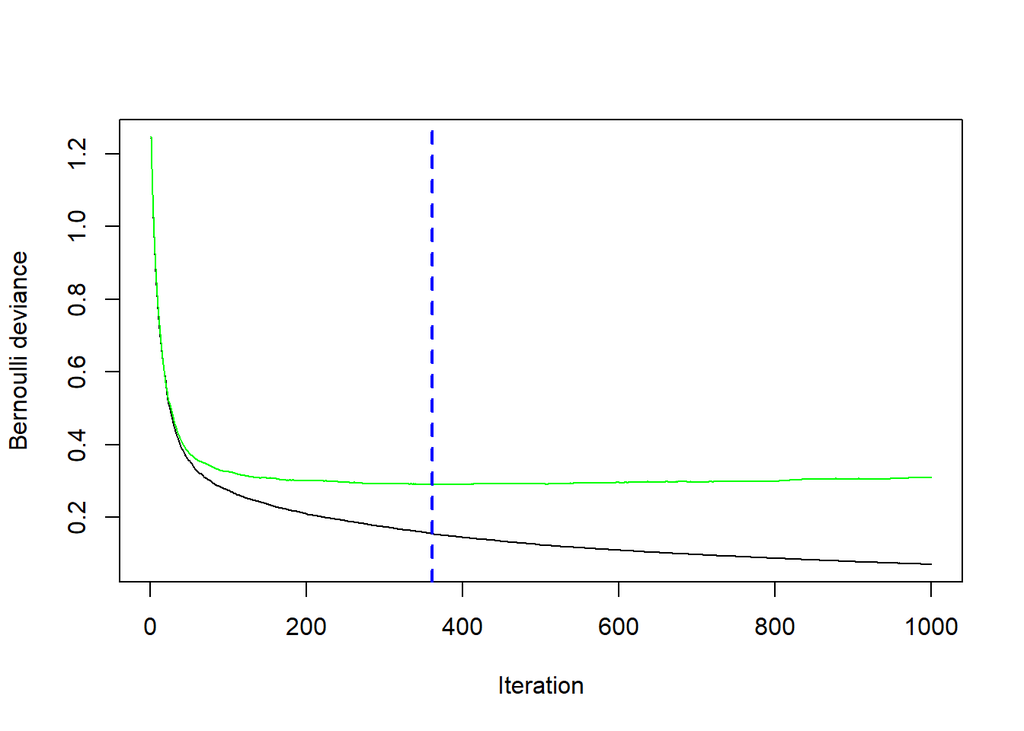

```
## [1] 361
```

```r
# plot loss as a function of the number of boosting iteration
gbm.perf(fit.boost, method = "cv")
```

We plot the relative influence of each variable:

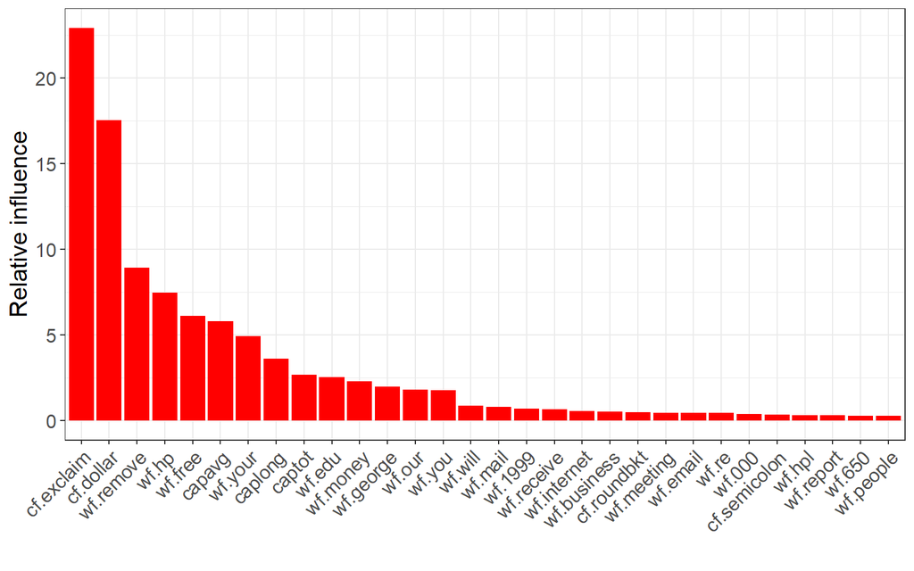

```r
drelimp <- summary(fit.boost,plotit=FALSE)%>%
  data.frame

drelimp2 <- drelimp%>%
  slice(1:30)

drelimp2%>%
  ggplot(.,aes(x=reorder(var,-rel.inf),y=rel.inf))+
  geom_bar(stat="identity",fill="red")+
  theme_bw()+
  theme(axis.text.x = element_text(angle = 45, hjust = 1),
        text = element_text(size=15))+
  ylab("Relative influence")+
  xlab("")
```

Finally, we calculate the misclassification error.

```r
pred.boost <- ifelse(predict(fit.boost, newdata = spam.test,type="response")>0.5,1,0)
```

```
## Using 361 trees...
```

```r
(err.adaboost <- mean(spam.test$spam!=pred.boost))
```

```
## [1] 0.05729167
```

# 17 Multiple testing and gene expression

In this exercise we explore the issue of multiple testing using the gene expression data from the mouse experiment (see lecture slides).

1. Load the gene expression data set `esetmouse.rds` and explore the structure of the object (use the functions `str`, `dim`, `pData`, `expr`).
2. Carry out a two-sample t-test for a single gene and print the p-value.
3. Repeat 2. for all genes, generate a histogram of p-values and calculated the number of p-values < 0.05.
4. Perform multiple testing correction using the Bonferroni and FDR methods and count the number of significant genes (`p.adjust`).
5. Use the `limma` package to run the differential expression analysis and plot the result using a volcano plot (use the functions `lmFit`, `eBayes` and `volcanoplot`)

Solution to the exercise.

We load the `ExpressionSet`.

```r
library(Biobase)
esetmouse <- readRDS(file="data/esetmouse.rds")
class(esetmouse)
```

```
## [1] "ExpressionSet"
## attr(,"package")
## [1] "Biobase"
```

```r
dim(esetmouse)
```

```
## Features  Samples
##    15923       24
```

We can look at the expression values of the first sample and the first 6 genes.

```r
exprs(esetmouse)[1:6,1]
```

```
## 1367452_at 1367453_at 1367454_at 1367455_at 1367456_at 1367457_at
##  10.051651  10.163334  10.211724  10.334899  10.889349   9.666755
```

An overview on the phenotype data can be obtained using the following commands.

```r
table(pData(esetmouse)$strain)
```

```
##
##  A  B
## 12 12
```

We run a two-sample t-test for gene $j=11425$.

```r
x <- esetmouse$strain # strain information
y <- t(exprs(esetmouse)) # gene expressions matrix (columns refer to genes)

ttest <- t.test(y[,11425]~x,var.equal=TRUE)
ttest$statistic #tscore
```

```
##        t
## 1.774198
```

```r
ttest$p.value
```

```
## [1] 0.0898726
```

We calculate p-values for all genes, plot them as a histogram and count the number < 0.05.

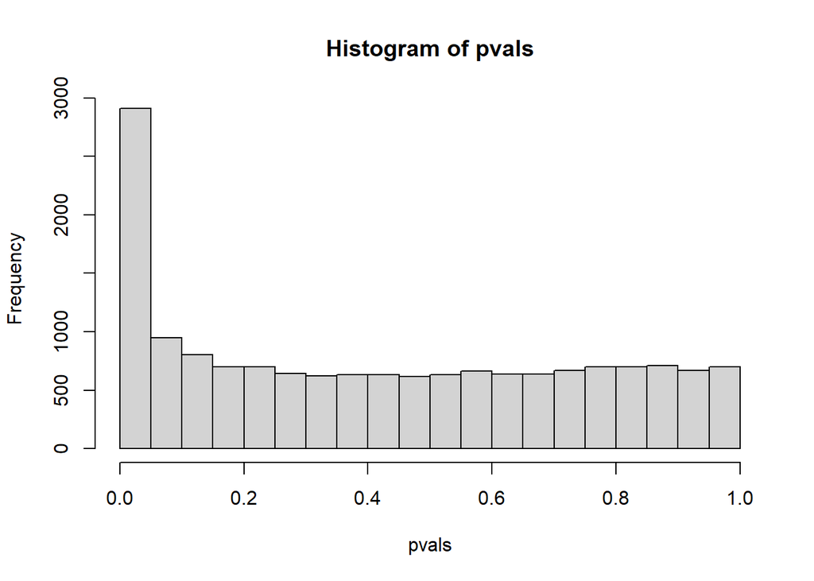

```r
pvals <- apply(y,2,FUN=
                 function(y){
                   t.test(y~x,var.equal=TRUE)$p.value
                 })
hist(pvals)
```

```r
sum(pvals<0.05)
```

```
## [1] 2908
```

We run the Bonferroni and FDR correction methods.

```r
sum(p.adjust(pvals,method="bonferroni")<0.05)
```

```
## [1] 82
```

```r
sum(p.adjust(pvals,method="fdr")<0.05)
```

```
## [1] 1123
```

Finally, we use the `limma` package to perform the differential expression analysis and we plot the results using a volcano plot.

```r
library(limma)
```

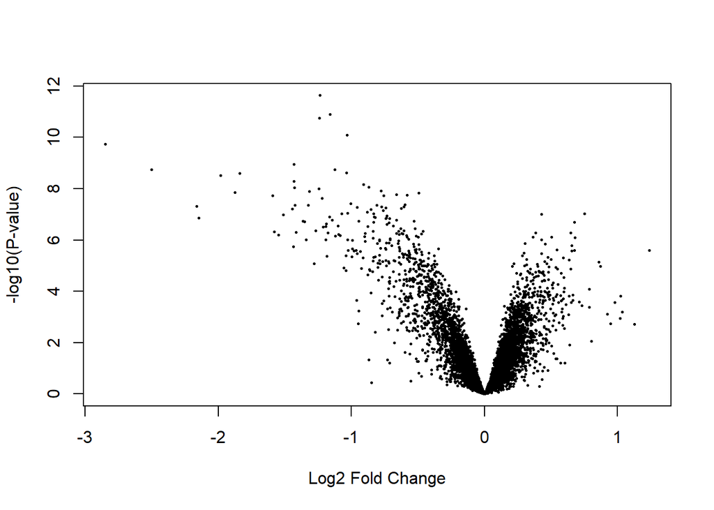

```r
# first argument: gene expression matrix with genes in rows and sample in columns
# second argument: design matrix
fit.limma <- lmFit(t(y), design=model.matrix(~ x))

# eBayes
ebfit <- eBayes(fit.limma)

# volcanplot
volcanoplot(ebfit,coef=2)
```